# Assignment 6

Tejas Athni

11/28/2020

INTRO & BACKGROUND: In this report, I analyze housing outcomes in Santa Clara County and land use in a particular census block group region in San Francisco. In particular, I focus on housing cost burden for those households with children aged 0-17 years old in Santa Clara County. Furthermore, I focus my land use analysis on the Inner Balboa Street Neighborhood Commercial District of San Francisco, a region defined by small-scale shopping, convenience goods and service, and limited comparison shopping goods for a broader market. This region also encourages neighborhood-serving businesses through its commercial development.

LIBRARIES: I load in the necessary R packages needed to perform the analyses.

```r
library(tidyverse)
library(sf)
library(tigris)
library(leaflet)
library(censusapi)
library(readxl)
library(lehdr)
library(mapboxapi)
library(dplyr)
library(rayshader)
library(tidycensus)
setwd("E:/SynologyDrive/Tejas_Server/! Stanford University/! Year 3 - Quarter 1/PoliSci 218X/Assignment 6")
Sys.setenv(CENSUS_KEY="0b20d8e27e52741cf293056779d3caf7e3793f0a")
census_api_key("0b20d8e27e52741cf293056779d3caf7e3793f0a")
readRenviron("~/.Renviron")
```

PART 1, HOUSING BURDEN ANALYSIS: I analyze the housing burden in Santa Clara County for the specific sub-population of those households whom have children aged 0-17 years old currently residing in the house. I use a burden threshold of 30% to estimate the total annual funding needed to eliminate this housing burden for the sub-population of interest, and visualize geospatially where this housing-burdened group resides.

```r
bay_counties <-
  counties("CA", cb = T, progress_bar = F) %>%
  filter(NAME == "Santa Clara")

ca_pumas <-
  pumas("CA", cb = T, progress_bar = F)

bay_pumas <-
  ca_pumas %>%
  st_centroid() %>%
  .[bay_counties, ] %>%
  st_set_geometry(NULL) %>%
  left_join(ca_pumas %>% select(GEOID10)) %>%
  st_as_sf()

pums_vars_2018 <-
  pums_variables %>%
  filter(year == 2018, survey == "acs5")


ca_pums <- get_pums(
  variables = c(
    "PUMA",
    "GRNTP",
    "SMOCP",
    "ADJHSG",
    "HINCP",
    "ADJINC",
    "HUPAOC"
  ),
  state = "CA",
  year = 2018,
  survey = "acs5"
)
```

```r
bay_pums <-
  ca_pums %>%
  filter(PUMA %in% bay_pumas$PUMACE10)



burden_threshold <- 0.3

bay_burden <-
  bay_pums %>%
  filter(HUPAOC %in% c(1,2,3)) %>%
  filter(HINCP > 0) %>%
  filter(SPORDER == 1) %>%
  transmute(
    PUMA = PUMA,
    weight = WGTP,
    housingcost = ifelse(
      SMOCP > 0,
      SMOCP*12*as.numeric(ADJHSG),
      GRNTP*12*as.numeric(ADJHSG)
    ),
    income = HINCP*as.numeric(ADJINC),
    burden_perc = housingcost/income,
    burden_30 = housingcost - burden_threshold*income,
    incomegap_30 = housingcost/burden_threshold - income
  )



bay_burden_pumas <-
  bay_burden %>%
  mutate(
    burdened_30 = ifelse(
      burden_perc >= burden_threshold,
      weight,
      0
    ),
    excess_30 = ifelse(
      burden_30 < 0,
      burden_30,
      0
    ),
    burden_30 = ifelse(
      burden_30 > 0,
      burden_30,
      0
    ),
    incomegap_30 = ifelse(
      incomegap_30 > 0,
      incomegap_30,
      0
    )
  ) %>%
  group_by(PUMA) %>%
  summarize(
    burdened_30 = sum(burdened_30),
    households = sum(weight),
    burden_30 = sum(burden_30*weight),
    incomegap_30 = sum(incomegap_30*weight),
    excess_30 = sum(excess_30*weight)
  ) %>%
  mutate(
    burdened_30_perc = burdened_30/households
  ) %>%
  left_join(bay_pumas %>% select(PUMA = PUMACE10)) %>%
  st_as_sf()



sum(bay_burden_pumas$burdened_30)/sum(bay_burden_pumas$households)
```

```
## [1] 0.3392637
```

```r
sum(bay_burden_pumas$burden_30)
```

```
## [1] 903043771
```

```r
burden_pal1 <- colorNumeric(
  palette = "Purples",
  domain = bay_burden_pumas$burdened_30_perc
)

bay_burden_pumas %>%
  leaflet() %>%
  addMapboxTiles(
    style_id = "streets-v11",
    username = "mapbox"
  ) %>%
  addPolygons(
    fillColor = ~burden_pal1(burdened_30_perc),
    fillOpacity = 0.5,
    color = "white",
    weight = 0.5,
    label = ~paste0(round(burdened_30_perc*100), "% of households with children (0-17 y/o) paying 30%+ of income on housing"),
    highlightOptions = highlightOptions(
      weight = 2
    )
  ) %>%
  addLegend(
    pal = burden_pal1,
    values = ~burdened_30_perc,
    title = "% Cost-Burdened<br>Households of <br>All Households<br> in Santa Clara County<br>with Children<br>Aged 0-17 Years Old"
  )
```

[interactive chart not shown]

```r
burden_pal2 <- colorNumeric(
  palette = "Reds",
  domain = bay_burden_pumas$burden_30/1e6
)

bay_burden_pumas %>%
  leaflet() %>%
  addMapboxTiles(
    style_id = "streets-v11",
    username = "mapbox"
  ) %>%
  addPolygons(
    fillColor = ~burden_pal2(burden_30/1e6),
    fillOpacity = 0.5,
    color = "white",
    weight = 0.5,
    label = ~paste0("$", round(burden_30/1e6), "M total annual cost burden"),
    highlightOptions = highlightOptions(
      weight = 2
    )
  ) %>%
  addLegend(
    pal = burden_pal2,
    values = ~burden_30/1e6,
    title = "Total housing cost<br>burden for households<br>in Santa Clara County<br>with children 0-17 y/o<br>in $ millions"
  )
```

[interactive chart not shown]

PART 1, RESULTS & DISCUSSION: I have found that roughly 33.93% of Santa Clara-residing households with children aged 0-17 years can be classified under housing cost burdened status. In order to alleviate this cost burden, roughly over $903 million in 2018 US dollars (i.e., federal funding in the form of housing vouchers, perhaps) would technically eliminate the issue of housing affordability. From a geographic point of view, it seems that the highest portion of the cost-burdened sub-population of households with 0-17 y/o children reside in inner city San Jose (near 50%), while surrounding regions have a noticeably less cost-burdened percentage of the sub-population. The Los Gatos and western portion of Mountain View have the numerical highest total housing cost burden for households with children, roughly at an aggregated 105 million USD each, even though these regions do not have the highest proportion of households with cost-burden status. Inner city San Jose near Communications Hill, though, has both a high net aggregate housing burden cost at 88 million USD as well as a high percentage of households cost-burdened.

PART 2, PROPERTY USE ANALYSIS: Here, I analyze land use in the San Francisco census tract #045100, block group #2, which resides squarely within the Inner Balboa Street Commercial Neighborhood District and adjacent to Golden Gate Park.

```r
sf_parcels_shape <-
  st_read("https://data.sfgov.org/api/geospatial/acdm-wktn?method=export&format=GeoJSON") %>%
  filter(active == "true") %>%
  select(
    apn = blklot,
    zoning = zoning_code,
    zoning_desc = zoning_district
  )
temp <- tempfile()
download.file("https://sfassessor.org/sites/default/files/uploaded/2020.7.10_SF_ASR_Secured_Roll_Data_2019-2020.xlsx",destfile = temp, mode = "wb")

sf_secured <- read_excel(temp, sheet = "Roll Data 2019-2020")
datakey <- read_excel(temp, sheet = "Data Key")
usecode <- read_excel(temp, sheet = "Class Code Only")

unlink(temp)
datakey %>% select(`DATA NAME`, `FIELD NAME`) %>% as.data.frame()
```

```
##     DATA NAME                               FIELD NAME
## 1     PROPLOC                        Property Location
## 2   RP1NBRCDE                        Neighborhood Code
## 3   RP1PRCLID                     Block and Lot Number
## 4   RP1VOLUME                            Volume Number
## 5   RP1CLACDE                      Property Class Code
## 6       YRBLT                      Year Property Built
## 7       BATHS                      Number of Bathrooms
## 8        BEDS                       Number of Bedrooms
## 9       ROOMS                          Number of Rooms
## 10   STOREYNO                        Number of Stories
## 11      UNITS                          Number of Units
## 12       ZONE                              Zoning Code
## 13  CONSTTYPE                        Construction Type
## 14      DEPTH                                Lot Depth
```

[output cut: 18 more lines]

```r
sf_parcels <-
  sf_parcels_shape %>%
  left_join(
    sf_secured %>%
      mutate(
        apn = RP1PRCLID %>%
          str_replace(" ","")
      )
  )


block_group_sample <-
  block_groups("CA", "San Francisco", cb = T, progress_bar = F) %>%
  filter(
    TRACTCE == "045100" & BLKGRPCE == "2") %>%
  st_transform(4326)

block_group_parcels <-
  sf_parcels %>%
  st_centroid() %>%
  .[block_group_sample, ] %>%
  st_set_geometry(NULL) %>%
  left_join(sf_parcels %>% select(apn)) %>%
  st_as_sf() %>%
  filter(!is.na(RP1PRCLID))
block_group_parcels %>%
  leaflet() %>%
  addMapboxTiles(
    style_id = "streets-v11",
    username = "mapbox"
  ) %>%
  addPolygons(
    fillColor = "blue",
    color = "black",
    weight = 0.5,
    label = ~zoning
  )
```

[interactive chart not shown]

```r
duplicate_shapes <-
  block_group_parcels %>%
  as.data.frame() %>%
  filter(duplicated(geometry))

condo_parcels <-
  block_group_parcels %>%
  filter(geometry %in% duplicate_shapes$geometry)


block_group_parcels %>%
  st_set_geometry(NULL) %>%
  group_by(zoning, zoning_desc) %>%
  summarize(Freq = n())
```

```
## # A tibble: 6 x 3
## # Groups:   zoning [6]
##   zoning zoning_desc                           Freq
##   <chr>  <chr>                                <int>
## 1 NC-1   NEIGHBORHOOD COMMERCIAL, CLUSTER         6
## 2 NC-2   NEIGHBORHOOD COMMERCIAL, SMALL SCALE    12
## 3 RH-1   RESIDENTIAL- HOUSE, ONE FAMILY          60
## 4 RH-2   RESIDENTIAL- HOUSE, TWO FAMILY         182
## 5 RH-3   RESIDENTIAL- HOUSE, THREE FAMILY        30
## 6 RM-3   RESIDENTIAL- MIXED, MEDIUM DENSITY       7
```

```r
block_group_parcels_clean <-
  block_group_parcels %>%
  filter(zoning != "P") %>%
  as.data.frame() %>%
  mutate(geometry = geometry %>% st_as_text()) %>%
  group_by(geometry) %>%
  summarize(
    apn = first(apn),
    zoning = first(zoning),
    units = sum(UNITS, na.rm = T),
    stories = max(STOREYNO, na.rm = T),
    floorarea = sum(SQFT, na.rm = T)
  ) %>%
  ungroup() %>%
  select(-geometry) %>%
  left_join(block_group_parcels %>% select(apn)) %>%
  st_as_sf()



sf_heights <- st_read("https://data.sfgov.org/resource/h9wh-cg3m.geojson")
block_group_heights <-
  sf_heights[block_group_parcels_clean, ]


projection <- "+proj=utm +zone=10 +ellps=GRS80 +datum=NAD83 +units=ft +no_defs"

block_group_parcels_zoning <-
  block_group_parcels_clean %>%
  st_centroid() %>%
  st_set_geometry(NULL) %>%
  left_join(block_group_parcels_clean %>% select(apn)) %>%
  st_as_sf() %>%
  st_transform(projection) %>%
  mutate(
    lotarea = st_area(.) %>% as.numeric(),
    max_floorarea = case_when(
      zoning %in% c("NC-1","NC-2") ~ lotarea*2.5,
      zoning %in% c("RH-1","RH-2","RH-3") ~ lotarea*1.8,
      zoning == "RM-3" ~ lotarea*3.6
    ),
    unused_floorarea = ifelse(
      (max_floorarea - floorarea) > 0,
      (max_floorarea - floorarea),
      0
    ),
    max_units = case_when(
      zoning %in% c("NC-1","NC-2") ~ floor(lotarea/800),
      zoning == "RH-1" ~ 1,
      zoning == "RH-2" ~ 2,
      zoning == "RH-3" ~ 3,
      zoning == "RM-3" ~ pmax(3, floor(lotarea/400))
    ),
    unused_units = ifelse(
      (max_units - units) > 0,
      (max_units - units),
      0
    ),
    max_height = 40,
    max_stories = floor(max_height/11),
    unused_stories = ifelse(
      (max_stories - stories) > 0,
      (max_stories - stories),
      0
    )
  ) %>%
  st_transform(4326)




sum(block_group_parcels_zoning$unused_floorarea, na.rm = T)
```

```
## [1] 704781.8
```

```r
sum(block_group_parcels_zoning$unused_units, na.rm = T)
```

```
## [1] 126
```

```r
sum(block_group_parcels_zoning$unused_stories, na.rm = T)
```

```
## [1] 307
```

```r
units_pal <- colorBin(
  palette = "Purples",
  bins = c(0,1,2,3,4,max(block_group_parcels_zoning$unused_units, na.rm = T))
)

leaflet() %>%
  addMapboxTiles(
    style_id = "light-v9",
    username = "mapbox"
  ) %>%
  addPolygons(
    data = block_group_parcels_zoning,
    fillColor = ~units_pal(unused_units),
    fillOpacity = 0.75,
    color = "white",
    weight = 0.5,
    label = ~round(unused_units)
  ) %>%
  addLegend(
    data = block_group_parcels_zoning,
    pal = units_pal,
    values = ~unused_units,
    title = "Additional Units<br>Allowed"
  )
```

[interactive chart not shown]

PART 2, ASSUMPTIONS: As acquired from the American Legal Code Library website, the NC-1 and NC-2 districts (i.e., these are non-residential districts) within the Inner Balboa Street Commercial region have a max floor-to-area ratio (FAR) limitation of 2.5 to 1, sourced from document SEC 735. For the three RH districts, FAR is 1.8 to 1. The one RM district, RM-3, has a FAR of 3.6. As it pertains to max dwelling units, the NC district is 1 unit per 800 square foot or whatever is permitted in the nearest residential district; for simplicity, I have chosen the first formula. For all RH districts, the number is the max number of units, while RM-3 is 1 unit per 400 square ft. Additionally, there are no special commercial areas and associated height restrictions in this block group of interest besides the standard 40 ft restriction and RH residential 35 ft restriction.

PART 2, RESULTS & DISCUSSION: In this specific block group within the Inner Balboa Street district, there is about 705,000 square feet of unused floor area that could be built upon within the current zoning. This signifies that currently, the land is under-utilized. Furthermore, there are about 126 unused dwelling units; this means that if all of the under-utilized space were to be allocated to housing, this could result in about 126 more dwelling units without any change to zoning policy. Additionally, there are 307 unused stories in this block group given no changes to zoning policy, signifying there is “vertical” room for expansion in this area while still meeting zoning requirements.

Geospatially, it appears that large clusters of 4-5 unused dwelling units each appear in the south-western tip of the block group, an area which is adjacent to and essentially touches Golden Gate Park. This area could serve as a target for increased unit construction and expansion to meet housing needs. There are also scattered regions of moderately unused dwelling units (e.g., 1-2 unused units) in the top 3 “rectangular chunks” of parcels, while noticeably there are zero unused dwelling units in the bottom right rectangular chunk.

```r
floorarea_pal <- colorBin(
  palette = "Greens",
  bins = c(0,1000,2500,5000,max(block_group_parcels_zoning$unused_floorarea, na.rm = T))
)

leaflet() %>%
  addMapboxTiles(
    style_id = "light-v9",
    username = "mapbox"
  ) %>%
  addPolygons(
    data = block_group_parcels_zoning,
    fillColor = ~floorarea_pal(unused_floorarea),
    fillOpacity = 0.75,
    color = "white",
    weight = 0.5,
    label = ~round(unused_floorarea)
  ) %>%
  addLegend(
    data = block_group_parcels_zoning,
    pal = floorarea_pal,
    values = ~unused_floorarea,
    title = "Unused Floor Area"
  )
```

[interactive chart not shown]

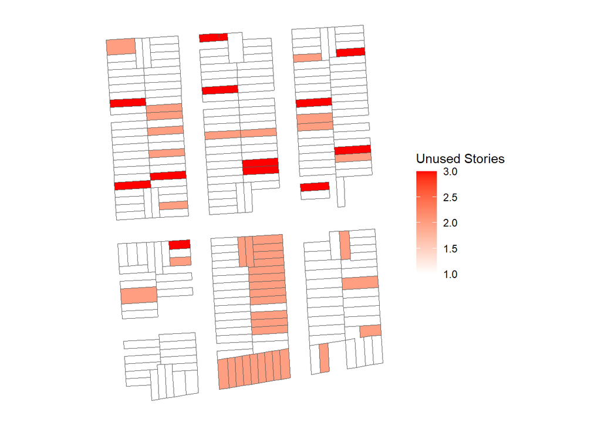

```r
stories_plot <-
  block_group_parcels_zoning %>%
  filter(unused_stories > 0) %>%
  ggplot() +
  geom_sf(
    aes(
      fill = unused_stories
    ),
    lwd = 0
  ) +
  theme(
    axis.text.x = element_blank(),
    axis.text.y = element_blank(),
    axis.ticks = element_blank(),
    rect = element_blank()
  ) +
  labs(
    fill = "Unused Stories"
  ) +
  scale_fill_gradient(
    low = "white",
    high = "red"
  )

stories_plot
```

```r
plot_gg(
  stories_plot,
  width = 10,
  height = 4,
  scale = 100
)

render_snapshot(
  "snapshot.png",
  clear = TRUE
)
```

UNUSED FLOOR AREA ANALYSIS: There is much unused floor area in this specific census block group of interest, with a vast majority of the unused floor area residing within the 2,500 - 5,000 square feet bin. In the south-western tip of the block group, there is a cluster of vastly underused floor area, with each parcel having 5,000+ unused square feet. Unlike the unused dwelling units analysis performed above, there are no specific “chunks” of the region that uniformly have zero unused floor area, except for a few individual parcels near the southern tips of the upper-middle and upper-right rectangular chunks.